# Data Processing for Visualization

Cheng Peng

# 1 Introduction

Data visualization is a form of data analysis (also called visual analytics). This means we need to prepare data sets that are appropriate for visualizations. Recall the following work flow of data visualizations mentioned in earlier notes.

[figure not shown]

Data visualization work-flow.

```r
include_graphics("img/Workflow.png")
```

The major data management tasks are data aggregation and extraction.

- **Information Aggregation** - combining information in different relational data sets to make an integrated single data set for data visualization.
- **Information Extraction** - subsetting a single data set to make small data sets that have specific information for creating a visualization.

The base R package has some powerful and easy-to-use functions to perform these types of data management.

# 2 Data Cleaning and Preparation for Visualization

## 2.1 Data Cleaning

Data cleaning refers to the process of making a data set possibly from different sources of `raw data` for modeling, visualization, and relevant analysis. Before starting cleaning, we need to create a backup plan of the original data (master data files) since things can go wrong easily the data processing stage. It’s important to create and stick to a plan for backing up your data.

- Store a copy of your master files in a separate location from your working files
- Set up a regular backup schedule
  - What files will be backed up?
  - How frequently will the files be backed up?

All data cleaning tasks must be performed based on the working data files. The major tasks vary from projects to projects, some of the common tasks are listed in the following:

- Removing unnecessary variables
  - observation ID
  - Irrelevant variables
- Deleting duplicate rows/observations
  - **Caution**: Never do this in bootstrap samples!
- Addressing outliers or invalid data
  - Genuine observation?
  - mistakenly recorded data points?
- Dealing with missing values
  - Missing value - the exists but for was not recorded
  - Null value - the value does not exist
- Standardizing or categorizing values
  - **Caution with standardizing!**
  - Combining sparse categories in a meaningful way.
  - Discrtizing continuous variables.
- Correcting typographical errors
- Data Augmentation or Extension
  - Adding new columns to the existing dataset
  - Combining existing dataset with another dataset

## 2.2 Data Preparation for Visualization

For a specific data analysis such as modeling or data visualization, we need to create an analytic data set based on clean data sets.

**Formatting/Conversion**

- Formatting columns appropriately (numbers are treated as numbers, dates as dates)
- Convert values into appropriate units

**Filtering/Subsetting**

- Filter your data to focus on the specific data that interests you.
- Group data and create aggregate values for groups (Counts, Min, Max, Mean, Median, Mode)
- Extract values from complex columns

**Aggregation/Merging**

- Combine variables to create new columns
- Merge different relational data sets

# 3 Basic Data Management: Merging Data Sets

There are different packages in R that have various functions capable of doing data management. In this note, we introduce the commonly used functions in base R and `tidyverse`.

## 3.1 Merge Data Sets

It is very common that the information we are interested in resides in different data sources. In order to merge different data sets, there must be at least one variable “key” that links to different data sets.

There are several different operations in SQL to create different types of the merged data set. The following are the most commonly used ones.

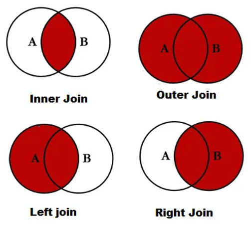

```r
include_graphics("img/joins.png")
```

The next figure shows the basic operations with tiny tables illustrating the operations.

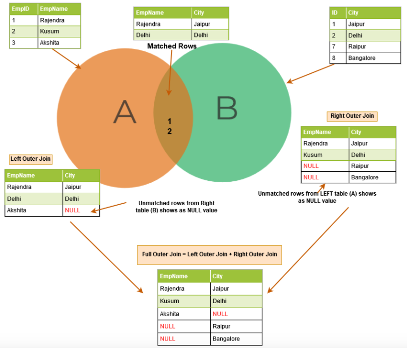

```r
include_graphics("img/JoinExamples.png")
```

## 3.2 Merging Data in Base R

The base R function `merge()` can be used to perform different joins. To illustrate, we use the tiny toy data set in the above figure to show you how to use `merge()` function.

- Defining Data Frames

```r
employee = data.frame(EmpID = c(1,2,3),
                      EmpName = c("Rajendra", "Kusum", "Akshita"))
city = data.frame(ID = c(1,2,7,8),
                  City =c("Jaipur", "Delhi", "Raipur", "Bangalore"))
```

- Inner Join

```r
innerjoin = merge(x=employee, city, by.x = 'EmpID', by.y ='ID', all = FALSE)
innerjoin
```

```
  EmpID  EmpName   City
1     1 Rajendra Jaipur
2     2    Kusum  Delhi
```

- Outer Join

```r
innerjoin = merge(x = employee, y = city, by.x = 'EmpID', by.y ='ID', all = TRUE)
innerjoin
```

```
  EmpID  EmpName      City
1     1 Rajendra    Jaipur
2     2    Kusum     Delhi
3     3  Akshita      <NA>
4     7     <NA>    Raipur
5     8     <NA> Bangalore
```

- Left Join

```r
leftjoin = merge(x = employee, y = city, by.x = 'EmpID', by.y ='ID', all.x = TRUE)
leftjoin
```

```
  EmpID  EmpName   City
1     1 Rajendra Jaipur
2     2    Kusum  Delhi
3     3  Akshita   <NA>
```

- Right Join

```r
rightjoin = merge(x = employee, y = city, by.x = 'EmpID', by.y ='ID', all.y = TRUE)
rightjoin
```

```
  EmpID  EmpName      City
1     1 Rajendra    Jaipur
2     2    Kusum     Delhi
3     7     <NA>    Raipur
4     8     <NA> Bangalore
```

## 3.3 Merging Data with Mutating Joins in **dplyr**

The package **dplyr** has the following four join functions corresponding to the options in the base R function ’merge()`.

The mutating joins add columns from y to x, matching rows based on the keys:

- `inner_join()`: includes all rows in x and y.
- `left_join()`: includes all rows in x.
- `right_join()`: includes all rows in y.
- `full_join()` (also called **outer join**): includes all rows in x or y (also called outer join)..

If a row in x matches multiple rows in y, all the rows in y will be returned once for each matching row in x.

To use mutating joins, we first rename key variables so that primary keys have the same name.

For large tables dplyr join functions is much faster than merge(). The advantages of using dplyr package for merging dataframes are:

1. They are much faster.
2. Shows the keys explicitly when merging data.
3. They are flexible and work with database tables.

The following are simple illustrative examples.

```r
employee.new = employee
employee.new$ID = employee$EmpID  # adding the new renamed ID
employee.new = employee.new[, -1]     # drop the old ID variable
employee.new
```

```
   EmpName ID
1 Rajendra  1
2    Kusum  2
3  Akshita  3
```

- Inner Join

```r
inner_join(employee.new, city, by = "ID")
```

```
   EmpName ID   City
1 Rajendra  1 Jaipur
2    Kusum  2  Delhi
```

- Left Join

```r
left_join(employee.new, city, by = "ID")
```

```
   EmpName ID   City
1 Rajendra  1 Jaipur
2    Kusum  2  Delhi
3  Akshita  3   <NA>
```

- right Join

```r
right_join(employee.new, city, by = "ID")
```

```
   EmpName ID      City
1 Rajendra  1    Jaipur
2    Kusum  2     Delhi
3     <NA>  7    Raipur
4     <NA>  8 Bangalore
```

- Full (Outer) Join

```r
full_join(employee.new, city, by = "ID")
```

```
   EmpName ID      City
1 Rajendra  1    Jaipur
2    Kusum  2     Delhi
3  Akshita  3      <NA>
4     <NA>  7    Raipur
5     <NA>  8 Bangalore
```

## 3.4 Use of Pipe Operator `%>%` with Mutating Joins

The pipe operator, written as `%>%` takes the output of one function and passes it into another function as an argument. This allows us to link *a sequence of analysis steps* using functions in `dplyr` and `tidyr` in data wrangling.

- Inner Join

```r
pipe.innerjoin <- employee %>% inner_join(city, by = c("EmpID" = "ID"))
pipe.innerjoin
```

```
  EmpID  EmpName   City
1     1 Rajendra Jaipur
2     2    Kusum  Delhi
```

- Full (Outer) Join

```r
pipe.outerjoin <- employee %>% full_join(city, by = c("EmpID" = "ID"))
pipe.outerjoin
```

```
  EmpID  EmpName      City
1     1 Rajendra    Jaipur
2     2    Kusum     Delhi
3     3  Akshita      <NA>
4     7     <NA>    Raipur
5     8     <NA> Bangalore
```

- Left Join

```r
pipe.leftjoin <- employee %>% left_join(city, by = c("EmpID" = "ID"))
pipe.leftjoin
```

```
  EmpID  EmpName   City
1     1 Rajendra Jaipur
2     2    Kusum  Delhi
3     3  Akshita   <NA>
```

- Right Join

```r
pipe.rightjoin <- employee %>% right_join(city, by = c("EmpID" = "ID"))
pipe.rightjoin
```

```
  EmpID  EmpName      City
1     1 Rajendra    Jaipur
2     2    Kusum     Delhi
3     7     <NA>    Raipur
4     8     <NA> Bangalore
```

# 4 Basic Data Management: Subsetting Data

Another important data management task is to subset data sets to extract the desired information for analyses and visualization.

Two operations are used to subset a data set: select/drop columns and select rows that meet certain conditions.

The working data set in the section is the well-known `iris` data set that has 4 numerical variables (attributes of iris flowers) and a categorical variable (species of iris flowers).

## 4.1 Accessors in R `[`, `[[` and `$`

When subsetting a data set, it is unavoidable to access the value(s) of certain variable(s). Three R accessors are commonly used in R coding.

- `[` subsetting a data set

This R accessor is probably the most commonly used. When we want a subset of an object using `[`. Remember that when we take a subset of the object you get `the same type` of thing. Thus, the subset of a vector will be a vector, the subset of a list will be a list and the subset of a data.frame will be a data.frame.

- `[[` extracting one item

The double square brackets are used to extract one element from potentially many. For vectors yield vectors with a single value; data frames give a column vector; for a list, one element:

For example,

```r
letters[[3]]            # extracts the third element in the vector of all lower case letters
```

```
[1] "c"
```

```r
iris[["Petal.Length"]]  # extract the variable named 'Petal.Length' in the data frame.
```

```
  [1] 1.4 1.4 1.3 1.5 1.4 1.7 1.4 1.5 1.4 1.5 1.5 1.6 1.4 1.1 1.2 1.5 1.3 1.4
 [19] 1.7 1.5 1.7 1.5 1.0 1.7 1.9 1.6 1.6 1.5 1.4 1.6 1.6 1.5 1.5 1.4 1.5 1.2
 [37] 1.3 1.4 1.3 1.5 1.3 1.3 1.3 1.6 1.9 1.4 1.6 1.4 1.5 1.4 4.7 4.5 4.9 4.0
 [55] 4.6 4.5 4.7 3.3 4.6 3.9 3.5 4.2 4.0 4.7 3.6 4.4 4.5 4.1 4.5 3.9 4.8 4.0
 [73] 4.9 4.7 4.3 4.4 4.8 5.0 4.5 3.5 3.8 3.7 3.9 5.1 4.5 4.5 4.7 4.4 4.1 4.0
 [91] 4.4 4.6 4.0 3.3 4.2 4.2 4.2 4.3 3.0 4.1 6.0 5.1 5.9 5.6 5.8 6.6 4.5 6.3
[109] 5.8 6.1 5.1 5.3 5.5 5.0 5.1 5.3 5.5 6.7 6.9 5.0 5.7 4.9 6.7 4.9 5.7 6.0
[127] 4.8 4.9 5.6 5.8 6.1 6.4 5.6 5.1 5.6 6.1 5.6 5.5 4.8 5.4 5.6 5.1 5.1 5.9
[145] 5.7 5.2 5.0 5.2 5.4 5.1
```

The double square bracket looks as if we are asking for something deep within a container. We are not taking a slice but reaching to get at the one thing at the core.

- Interact with `$`

The accessor that provides the least unique utility is also probably used the most often used. `$` is a special case of `[[` in which we access a single item by actual name. The following are equivalent:

```r
iris$Petal.Length
```

```
  [1] 1.4 1.4 1.3 1.5 1.4 1.7 1.4 1.5 1.4 1.5 1.5 1.6 1.4 1.1 1.2 1.5 1.3 1.4
 [19] 1.7 1.5 1.7 1.5 1.0 1.7 1.9 1.6 1.6 1.5 1.4 1.6 1.6 1.5 1.5 1.4 1.5 1.2
 [37] 1.3 1.4 1.3 1.5 1.3 1.3 1.3 1.6 1.9 1.4 1.6 1.4 1.5 1.4 4.7 4.5 4.9 4.0
 [55] 4.6 4.5 4.7 3.3 4.6 3.9 3.5 4.2 4.0 4.7 3.6 4.4 4.5 4.1 4.5 3.9 4.8 4.0
 [73] 4.9 4.7 4.3 4.4 4.8 5.0 4.5 3.5 3.8 3.7 3.9 5.1 4.5 4.5 4.7 4.4 4.1 4.0
 [91] 4.4 4.6 4.0 3.3 4.2 4.2 4.2 4.3 3.0 4.1 6.0 5.1 5.9 5.6 5.8 6.6 4.5 6.3
[109] 5.8 6.1 5.1 5.3 5.5 5.0 5.1 5.3 5.5 6.7 6.9 5.0 5.7 4.9 6.7 4.9 5.7 6.0
[127] 4.8 4.9 5.6 5.8 6.1 6.4 5.6 5.1 5.6 6.1 5.6 5.5 4.8 5.4 5.6 5.1 5.1 5.9
[145] 5.7 5.2 5.0 5.2 5.4 5.1
```

```r
iris[["Petal.Length"]]
```

```
  [1] 1.4 1.4 1.3 1.5 1.4 1.7 1.4 1.5 1.4 1.5 1.5 1.6 1.4 1.1 1.2 1.5 1.3 1.4
 [19] 1.7 1.5 1.7 1.5 1.0 1.7 1.9 1.6 1.6 1.5 1.4 1.6 1.6 1.5 1.5 1.4 1.5 1.2
 [37] 1.3 1.4 1.3 1.5 1.3 1.3 1.3 1.6 1.9 1.4 1.6 1.4 1.5 1.4 4.7 4.5 4.9 4.0
 [55] 4.6 4.5 4.7 3.3 4.6 3.9 3.5 4.2 4.0 4.7 3.6 4.4 4.5 4.1 4.5 3.9 4.8 4.0
 [73] 4.9 4.7 4.3 4.4 4.8 5.0 4.5 3.5 3.8 3.7 3.9 5.1 4.5 4.5 4.7 4.4 4.1 4.0
 [91] 4.4 4.6 4.0 3.3 4.2 4.2 4.2 4.3 3.0 4.1 6.0 5.1 5.9 5.6 5.8 6.6 4.5 6.3
[109] 5.8 6.1 5.1 5.3 5.5 5.0 5.1 5.3 5.5 6.7 6.9 5.0 5.7 4.9 6.7 4.9 5.7 6.0
[127] 4.8 4.9 5.6 5.8 6.1 6.4 5.6 5.1 5.6 6.1 5.6 5.5 4.8 5.4 5.6 5.1 5.1 5.9
[145] 5.7 5.2 5.0 5.2 5.4 5.1
```

## 4.2 Subsetting Data in Base R

**Selecting/Dropping Columns**

Subsetting a data set by selecting or dropping a subset of variables (columns) from a data set is straightforward.

For example, we can define a subset of the `iris` data set by selecting all numerical variables.

```r
iris.names = names(iris)
iris0 = iris[, iris.names[1:4]]
DT::datatable(iris0, fillContainer = FALSE, options = list(pageLength = 10))
```

|  | Sepal.Length | Sepal.Width | Petal.Length | Petal.Width |
| --- | --- | --- | --- | --- |
| 1 | 5.1 | 3.5 | 1.4 | 0.2 |
| 2 | 4.9 | 3 | 1.4 | 0.2 |
| 3 | 4.7 | 3.2 | 1.3 | 0.2 |
| 4 | 4.6 | 3.1 | 1.5 | 0.2 |
| 5 | 5 | 3.6 | 1.4 | 0.2 |
| 6 | 5.4 | 3.9 | 1.7 | 0.4 |
| 7 | 4.6 | 3.4 | 1.4 | 0.3 |
| 8 | 5 | 3.4 | 1.5 | 0.2 |
| 9 | 4.4 | 2.9 | 1.4 | 0.2 |
| 10 | 4.9 | 3.1 | 1.5 | 0.1 |

[output cut: 140 more lines]

We can also create the same data set by dropping variables in the original data set. For example

```r
iris02 = iris[, -5]
DT::datatable(iris02, fillContainer = FALSE, options = list(pageLength = 10))
```

|  | Sepal.Length | Sepal.Width | Petal.Length | Petal.Width |
| --- | --- | --- | --- | --- |
| 1 | 5.1 | 3.5 | 1.4 | 0.2 |
| 2 | 4.9 | 3 | 1.4 | 0.2 |
| 3 | 4.7 | 3.2 | 1.3 | 0.2 |
| 4 | 4.6 | 3.1 | 1.5 | 0.2 |
| 5 | 5 | 3.6 | 1.4 | 0.2 |
| 6 | 5.4 | 3.9 | 1.7 | 0.4 |
| 7 | 4.6 | 3.4 | 1.4 | 0.3 |
| 8 | 5 | 3.4 | 1.5 | 0.2 |
| 9 | 4.4 | 2.9 | 1.4 | 0.2 |
| 10 | 4.9 | 3.1 | 1.5 | 0.1 |

[output cut: 140 more lines]

**Selection/Dropping Rows**

This is also relatively straightforward. The basic idea is to identify row IDs to select or drop the corresponding rows. The R function `which()` can this trick!

The following example illustrates the way of using `which()` to subsetting data.

1. Selecting One Species of Iris Flowers

```r
setosa.id = which(iris$Species == "setosa")
setosa.flower = iris[setosa.id,]
DT::datatable(setosa.flower, fillContainer = FALSE, options = list(pageLength = 10))
```

|  | Sepal.Length | Sepal.Width | Petal.Length | Petal.Width | Species |
| --- | --- | --- | --- | --- | --- |
| 1 | 5.1 | 3.5 | 1.4 | 0.2 | setosa |
| 2 | 4.9 | 3 | 1.4 | 0.2 | setosa |
| 3 | 4.7 | 3.2 | 1.3 | 0.2 | setosa |
| 4 | 4.6 | 3.1 | 1.5 | 0.2 | setosa |
| 5 | 5 | 3.6 | 1.4 | 0.2 | setosa |
| 6 | 5.4 | 3.9 | 1.7 | 0.4 | setosa |
| 7 | 4.6 | 3.4 | 1.4 | 0.3 | setosa |
| 8 | 5 | 3.4 | 1.5 | 0.2 | setosa |
| 9 | 4.4 | 2.9 | 1.4 | 0.2 | setosa |
| 10 | 4.9 | 3.1 | 1.5 | 0.1 | setosa |

[output cut: 40 more lines]

2. Selecting Two Species of Iris Flowers

The following three code chunks create the same data set.

Method 1:

```r
not.setosa.id01 = which(iris$Species != "setosa")
not.setosa.flower01 = iris[not.setosa.id01,]
DT::datatable(not.setosa.flower01, fillContainer = FALSE, options = list(pageLength = 10))
```

|  | Sepal.Length | Sepal.Width | Petal.Length | Petal.Width | Species |
| --- | --- | --- | --- | --- | --- |
| 51 | 7 | 3.2 | 4.7 | 1.4 | versicolor |
| 52 | 6.4 | 3.2 | 4.5 | 1.5 | versicolor |
| 53 | 6.9 | 3.1 | 4.9 | 1.5 | versicolor |
| 54 | 5.5 | 2.3 | 4 | 1.3 | versicolor |
| 55 | 6.5 | 2.8 | 4.6 | 1.5 | versicolor |
| 56 | 5.7 | 2.8 | 4.5 | 1.3 | versicolor |
| 57 | 6.3 | 3.3 | 4.7 | 1.6 | versicolor |
| 58 | 4.9 | 2.4 | 3.3 | 1 | versicolor |
| 59 | 6.6 | 2.9 | 4.6 | 1.3 | versicolor |
| 60 | 5.2 | 2.7 | 3.9 | 1.4 | versicolor |

[output cut: 90 more lines]

Method 2:

```r
not.setosa.id02 = which(iris$Species == "virginica" | iris$Species =="versicolor")
not.setosa.flower02 = iris[not.setosa.id02,]
DT::datatable(not.setosa.flower02, fillContainer = FALSE, options = list(pageLength = 10))
```

|  | Sepal.Length | Sepal.Width | Petal.Length | Petal.Width | Species |
| --- | --- | --- | --- | --- | --- |
| 51 | 7 | 3.2 | 4.7 | 1.4 | versicolor |
| 52 | 6.4 | 3.2 | 4.5 | 1.5 | versicolor |
| 53 | 6.9 | 3.1 | 4.9 | 1.5 | versicolor |
| 54 | 5.5 | 2.3 | 4 | 1.3 | versicolor |
| 55 | 6.5 | 2.8 | 4.6 | 1.5 | versicolor |
| 56 | 5.7 | 2.8 | 4.5 | 1.3 | versicolor |
| 57 | 6.3 | 3.3 | 4.7 | 1.6 | versicolor |
| 58 | 4.9 | 2.4 | 3.3 | 1 | versicolor |
| 59 | 6.6 | 2.9 | 4.6 | 1.3 | versicolor |
| 60 | 5.2 | 2.7 | 3.9 | 1.4 | versicolor |

[output cut: 90 more lines]

Method 3:

```r
not.setosa.id03 = which(iris$Species %in% c("versicolor", "virginica"))
not.setosa.flower03 = iris[not.setosa.id01,]
DT::datatable(not.setosa.flower03, fillContainer = FALSE, options = list(pageLength = 10))
```

|  | Sepal.Length | Sepal.Width | Petal.Length | Petal.Width | Species |
| --- | --- | --- | --- | --- | --- |
| 51 | 7 | 3.2 | 4.7 | 1.4 | versicolor |
| 52 | 6.4 | 3.2 | 4.5 | 1.5 | versicolor |
| 53 | 6.9 | 3.1 | 4.9 | 1.5 | versicolor |
| 54 | 5.5 | 2.3 | 4 | 1.3 | versicolor |
| 55 | 6.5 | 2.8 | 4.6 | 1.5 | versicolor |
| 56 | 5.7 | 2.8 | 4.5 | 1.3 | versicolor |
| 57 | 6.3 | 3.3 | 4.7 | 1.6 | versicolor |
| 58 | 4.9 | 2.4 | 3.3 | 1 | versicolor |
| 59 | 6.6 | 2.9 | 4.6 | 1.3 | versicolor |
| 60 | 5.2 | 2.7 | 3.9 | 1.4 | versicolor |

[output cut: 90 more lines]

## 4.3 Subsetting Data with `dplyr`

**dplyr** provides helper tools for the most common data manipulation tasks. It is built to work directly with data frames and has the ability to work directly with data stored in an external database. We can conduct queries on the database directly and pull back into R only what we need for analysis.

Since selecting/dropping variables is straightforward (particularly when using %>%). Next, we provide a few examples showing how to use `filter()` to select/drop rows with certain conditions.

- Filtering by one criterion

```r
setosa = filter(iris, Species == "setosa")
DT::datatable(setosa, fillContainer = FALSE, options = list(pageLength = 10))
```

|  | Sepal.Length | Sepal.Width | Petal.Length | Petal.Width | Species |
| --- | --- | --- | --- | --- | --- |
| 1 | 5.1 | 3.5 | 1.4 | 0.2 | setosa |
| 2 | 4.9 | 3 | 1.4 | 0.2 | setosa |
| 3 | 4.7 | 3.2 | 1.3 | 0.2 | setosa |
| 4 | 4.6 | 3.1 | 1.5 | 0.2 | setosa |
| 5 | 5 | 3.6 | 1.4 | 0.2 | setosa |
| 6 | 5.4 | 3.9 | 1.7 | 0.4 | setosa |
| 7 | 4.6 | 3.4 | 1.4 | 0.3 | setosa |
| 8 | 5 | 3.4 | 1.5 | 0.2 | setosa |
| 9 | 4.4 | 2.9 | 1.4 | 0.2 | setosa |
| 10 | 4.9 | 3.1 | 1.5 | 0.1 | setosa |

[output cut: 40 more lines]

```r
iris.ge.6 = filter(iris, Sepal.Length > 6)
DT::datatable(iris.ge.6, fillContainer = FALSE, options = list(pageLength = 10))
```

|  | Sepal.Length | Sepal.Width | Petal.Length | Petal.Width | Species |
| --- | --- | --- | --- | --- | --- |
| 1 | 7 | 3.2 | 4.7 | 1.4 | versicolor |
| 2 | 6.4 | 3.2 | 4.5 | 1.5 | versicolor |
| 3 | 6.9 | 3.1 | 4.9 | 1.5 | versicolor |
| 4 | 6.5 | 2.8 | 4.6 | 1.5 | versicolor |
| 5 | 6.3 | 3.3 | 4.7 | 1.6 | versicolor |
| 6 | 6.6 | 2.9 | 4.6 | 1.3 | versicolor |
| 7 | 6.1 | 2.9 | 4.7 | 1.4 | versicolor |
| 8 | 6.7 | 3.1 | 4.4 | 1.4 | versicolor |
| 9 | 6.2 | 2.2 | 4.5 | 1.5 | versicolor |
| 10 | 6.1 | 2.8 | 4 | 1.3 | versicolor |

[output cut: 51 more lines]

- When multiple expressions are used, they are combined using `&` (logical AND) or `|` (logical OR)

```r
setosa.ge5 = filter(iris, Species == "setosa" & Sepal.Length > 5 )
DT::datatable(setosa.ge5, fillContainer = FALSE, options = list(pageLength = 10))
```

|  | Sepal.Length | Sepal.Width | Petal.Length | Petal.Width | Species |
| --- | --- | --- | --- | --- | --- |
| 1 | 5.1 | 3.5 | 1.4 | 0.2 | setosa |
| 2 | 5.4 | 3.9 | 1.7 | 0.4 | setosa |
| 3 | 5.4 | 3.7 | 1.5 | 0.2 | setosa |
| 4 | 5.8 | 4 | 1.2 | 0.2 | setosa |
| 5 | 5.7 | 4.4 | 1.5 | 0.4 | setosa |
| 6 | 5.4 | 3.9 | 1.3 | 0.4 | setosa |
| 7 | 5.1 | 3.5 | 1.4 | 0.3 | setosa |
| 8 | 5.7 | 3.8 | 1.7 | 0.3 | setosa |
| 9 | 5.1 | 3.8 | 1.5 | 0.3 | setosa |
| 10 | 5.4 | 3.4 | 1.7 | 0.2 | setosa |

[output cut: 12 more lines]

```r
setosa.ge7 = filter(iris, Species == "setosa" | Sepal.Length > 7 )
DT::datatable(setosa.ge7, fillContainer = FALSE, options = list(pageLength = 10))
```

|  | Sepal.Length | Sepal.Width | Petal.Length | Petal.Width | Species |
| --- | --- | --- | --- | --- | --- |
| 1 | 5.1 | 3.5 | 1.4 | 0.2 | setosa |
| 2 | 4.9 | 3 | 1.4 | 0.2 | setosa |
| 3 | 4.7 | 3.2 | 1.3 | 0.2 | setosa |
| 4 | 4.6 | 3.1 | 1.5 | 0.2 | setosa |
| 5 | 5 | 3.6 | 1.4 | 0.2 | setosa |
| 6 | 5.4 | 3.9 | 1.7 | 0.4 | setosa |
| 7 | 4.6 | 3.4 | 1.4 | 0.3 | setosa |
| 8 | 5 | 3.4 | 1.5 | 0.2 | setosa |
| 9 | 4.4 | 2.9 | 1.4 | 0.2 | setosa |
| 10 | 4.9 | 3.1 | 1.5 | 0.1 | setosa |

[output cut: 52 more lines]

- To refer to column names that are stored as strings, use the `.data` pronoun:

```r
vars <- c("Sepal.Length", "Petal.Length")
cond <- c(6, 5)
subset.iris <- iris %>%
  filter(
    .data[[vars[[1]]]] > cond[[1]],
    .data[[vars[[2]]]] < cond[[2]]
  )
#subset.iris
DT::datatable(subset.iris, fillContainer = FALSE, options = list(pageLength = 10))
```

|  | Sepal.Length | Sepal.Width | Petal.Length | Petal.Width | Species |
| --- | --- | --- | --- | --- | --- |
| 1 | 7 | 3.2 | 4.7 | 1.4 | versicolor |
| 2 | 6.4 | 3.2 | 4.5 | 1.5 | versicolor |
| 3 | 6.9 | 3.1 | 4.9 | 1.5 | versicolor |
| 4 | 6.5 | 2.8 | 4.6 | 1.5 | versicolor |
| 5 | 6.3 | 3.3 | 4.7 | 1.6 | versicolor |
| 6 | 6.6 | 2.9 | 4.6 | 1.3 | versicolor |
| 7 | 6.1 | 2.9 | 4.7 | 1.4 | versicolor |
| 8 | 6.7 | 3.1 | 4.4 | 1.4 | versicolor |
| 9 | 6.2 | 2.2 | 4.5 | 1.5 | versicolor |
| 10 | 6.1 | 2.8 | 4 | 1.3 | versicolor |

[output cut: 12 more lines]

## 4.4 Variable Definition and Variable Type Conversion

- Define New Variables

Defining new variables based on the existing variables is straightforward in R using the basic arithmetic and mathematical operations. When using `%>%`, `dplyr()` is used to define new variables.

- Variable Type Conversion

Type conversions in R work as you would expect. For example, adding a character string to a numeric vector converts all the elements in the vector to the character.

1. Use `is.foo` to test for data type foo. Returns TRUE or FALSE

`is.numeric(), is.character(), is.vector(), is.matrix(), is.data.frame()`

2. Use `as.foo` to explicitly convert it.

`as.numeric(), as.character(), as.vector(), as.matrix(), as.data.frame)`

# 5 Importing/Exporting Data

## 5.1 Importing Dara

There are different functions in various R libraries to read data to R.

- Base R and Libraries Come with Base R

R loading functions in {utils}: `read.table()`, `read.csv()`, `read.csv2()`, `read.delim()`, and `read.delim2()`

- Functions in {tidyverse}

As a part of {tidyverse}, the library {readr} has several functions to read the data in common formats.

`read_table(), read_delim(), read_csv(), read_csv2(), read_tsv()`

- Read data set generated by other programs such as SAS, SPSS, etc.

Several libraries are useful to load special formats of data to R. Three important libraries are

`{xlsx, Hmisc, foreign}`.

## 5.2 Exporting Data

We have learned how to use `dplyr` to extract information from or summarize your raw data, we may want to export these new data sets to share them with other people or for archival.

Similar to the `read_csv()` function used for reading CSV files into R, there is a `write_csv()` function that generates CSV files from data frames.

Let’s assume our data set under the name, `final_data`, is ready, we can save it as a CSV file in our `data` folder using the following code.

`write_csv(final_data, file = "data/final_data.csv")`

# 6 Overview of `Tidyverse`

There are several R libraries that have powerful tools for data wrangling and information extraction. Tidyverse is a collection of essential R packages for data science. There 8 packages under the `tidyverse umbrella` that help us in performing and interacting with the data.

## 6.1 Packages for Data Wrangling and Transformation

- **dplyr** provides helper tools for the most common data manipulation tasks. It is built to work directly with data frames and has the ability to work directly with data stored in an external database. We can conduct queries on the database directly, and pull back into R only what we need for analysis.
- **tidyr** addresses the common problem of wanting to reshape the data with a sophisticated layout for plotting and usage by different R functions.
- **stringr** deals with string variables. It plays a big role in processing raw data into a cleaner and easily understandable format.
- **forcats** is dedicated to dealing with categorical variables or factors. Anyone who has worked with categorical data knows what a nightmare they can be.

## 6.2 Packages for Data Import and Management

- **tibble** is a new modern data frame with nicer behavior around printing, subsetting, and factor handling. It keeps many important features of the original data frame and removes many of the outdated features.
- **readr** package is recently developed to deal with reading in large flat files quickly. The package provides replacements for functions like `read.table()` and `read.csv().` The analogous functions in {readr} are `read_table()` and `read_csv()`.

## 6.3 Functional Programming with Library **{purrr}**

- **purrr** is a new package that fills in the missing pieces in R’s functional programming tools. This is not a coding class. We will not use ‘purrr’ in this class.

## 6.4 Data Visualization and Exploration

**ggplot2** is a powerful and flexible R package for producing elegant graphics. The concept behind `ggplot2` divides plot into three different fundamental parts: `Plot = data + Aesthetics + Geometry`.

The principal components of every plot can be defined as follow:

- **Aesthetics** is used to indicate x and y variables. It can also be used to control the color, the size or the shape of points, the height of bars, etc.
- **Geometry** defines the type of graphics (histogram, box plot, line plot, density plot, dot plot, etc.)

This will be one of the primary tools for this class.

# 7 Data Management with `dplyr` (Optional)

What we can do in the standard SQL can also be done with `dyplr`. For the convenience of illustration, we use a simple well-known built-in `iris data set`.

## 7.1 Common `dplyr` Functions

The following is the list of functions in `dplyr`.

- **select()**: sub-setting columns.

To select columns of a data frame, use `select()`. The first argument to this function is the data frame (`iris`), and the subsequent arguments are the columns to keep. For example

```r
iris.petal = select(iris, Petal.Length, Petal.Width, Species)
str(iris.petal)
```

```
'data.frame':   150 obs. of  3 variables:
 $ Petal.Length: num  1.4 1.4 1.3 1.5 1.4 1.7 1.4 1.5 1.4 1.5 ...
 $ Petal.Width : num  0.2 0.2 0.2 0.2 0.2 0.4 0.3 0.2 0.2 0.1 ...
 $ Species     : Factor w/ 3 levels "setosa","versicolor",..: 1 1 1 1 1 1 1 1 1 1 ...
```

To select all columns except certain ones, put a “-” in front of the variable to exclude it. For example, we **exclude** Petal information and only **keep** Sepal information, we can use the following code

```r
iris.sepal = select(iris, -Petal.Length, -Petal.Width)
str(iris.sepal)
```

```
'data.frame':   150 obs. of  3 variables:
 $ Sepal.Length: num  5.1 4.9 4.7 4.6 5 5.4 4.6 5 4.4 4.9 ...
 $ Sepal.Width : num  3.5 3 3.2 3.1 3.6 3.9 3.4 3.4 2.9 3.1 ...
 $ Species     : Factor w/ 3 levels "setosa","versicolor",..: 1 1 1 1 1 1 1 1 1 1 ...
```

This will select all the variables in surveys except for `Petal.Length`, and `Petal.Width`.

- **filter()**: sub-setting rows on conditions.

For example, if we only select one species `Versicolor`, we can use the following code.

```r
versicolor = filter(iris, Species =="versicolor")
summary(versicolor)
```

```
  Sepal.Length    Sepal.Width     Petal.Length   Petal.Width          Species
 Min.   :4.900   Min.   :2.000   Min.   :3.00   Min.   :1.000   setosa    : 0
 1st Qu.:5.600   1st Qu.:2.525   1st Qu.:4.00   1st Qu.:1.200   versicolor:50
 Median :5.900   Median :2.800   Median :4.35   Median :1.300   virginica : 0
 Mean   :5.936   Mean   :2.770   Mean   :4.26   Mean   :1.326
 3rd Qu.:6.300   3rd Qu.:3.000   3rd Qu.:4.60   3rd Qu.:1.500
 Max.   :7.000   Max.   :3.400   Max.   :5.10   Max.   :1.800
```

If we subset a data set by selecting a certain number of columns and row with multiple conditions, pipe operator `%>%` will make subsetting easy. For example, if we only want to study `sepal width` and `length` of `setosa` where petal length is less than 1.5. The following code using `%>%`

```r
resulting.subset <- iris %>%
             filter(Petal.Length < 1.5, Species =="setosa") %>%
             select(Sepal.Length, Sepal.Width, Species)
summary(resulting.subset)
```

```
  Sepal.Length    Sepal.Width          Species
 Min.   :4.300   Min.   :2.300   setosa    :24
 1st Qu.:4.600   1st Qu.:3.000   versicolor: 0
 Median :4.900   Median :3.350   virginica : 0
 Mean   :4.896   Mean   :3.333
 3rd Qu.:5.100   3rd Qu.:3.525
 Max.   :5.800   Max.   :4.200
```

Note that, multiple conditional statements are separated by `,` or `&`. Using `%>%`, we don’t need to include the data set as the first argument.

- **mutate()**: creating new columns by using information from other columns.

Frequently we want to create new columns based on the values in existing columns. For example, we want to define two ratios of the sepal and petal widths and sepal and petal lengths. For this, we’ll use mutate().

```r
expanded.data <- iris %>%
             mutate(length.ratio = Sepal.Length/Petal.Length,
                    width.ratio = Sepal.Width/Petal.Width)
summary(expanded.data)
```

```
  Sepal.Length    Sepal.Width     Petal.Length    Petal.Width
 Min.   :4.300   Min.   :2.000   Min.   :1.000   Min.   :0.100
 1st Qu.:5.100   1st Qu.:2.800   1st Qu.:1.600   1st Qu.:0.300
 Median :5.800   Median :3.000   Median :4.350   Median :1.300
 Mean   :5.843   Mean   :3.057   Mean   :3.758   Mean   :1.199
 3rd Qu.:6.400   3rd Qu.:3.300   3rd Qu.:5.100   3rd Qu.:1.800
 Max.   :7.900   Max.   :4.400   Max.   :6.900   Max.   :2.500
       Species    length.ratio    width.ratio
 setosa    :50   Min.   :1.050   Min.   : 1.130
 versicolor:50   1st Qu.:1.230   1st Qu.: 1.603
 virginica :50   Median :1.411   Median : 2.148
                 Mean   :2.018   Mean   : 6.628
                 3rd Qu.:3.176   3rd Qu.:11.583
                 Max.   :4.833   Max.   :41.000
```

- **group_by()** and **summarize()**: creating summary statistics on grouped data.

‘group_by()’ is often used together with ‘summarize()’, which collapses each group into a single-row summary of that group. ‘group_by()’ takes as arguments the column names that contain the categorical variables for which you want to calculate the summary statistics.

The following code yields a set of summarized statistics including the mean of sepal width and length as well as the correlation coefficients in each of the three species.

```r
summary.stats <- iris %>%
             group_by(Species) %>%
             summarize(sepal.width.avg = mean(Sepal.Width),
                       sepal.length.avg = mean(Sepal.Length),
                       corr.sepal = cor(Sepal.Length, Sepal.Width))
summary.stats
```

```
# A tibble: 3 × 4
  Species    sepal.width.avg sepal.length.avg corr.sepal
  <fct>                <dbl>            <dbl>      <dbl>
1 setosa                3.43             5.01      0.743
2 versicolor            2.77             5.94      0.526
3 virginica             2.97             6.59      0.457
```

All R functions such as `min()`, `max()`, that yield summarized statistics can be used with `summarize()`. We can also filter out some observations before we compute the summary statistics.

```r
summary.stats.filtering <- iris %>%
             filter(Petal.Length < 5) %>%
             group_by(Species) %>%
             summarize(sepal.width.avg = mean(Sepal.Width),
                       sepal.length.avg = mean(Sepal.Length),
                       corr.sepal = cor(Sepal.Length, Sepal.Width))
summary.stats.filtering
```

```
# A tibble: 3 × 4
  Species    sepal.width.avg sepal.length.avg corr.sepal
  <fct>                <dbl>            <dbl>      <dbl>
1 setosa                3.43             5.01      0.743
2 versicolor            2.77             5.92      0.519
3 virginica             2.8              5.85      0.643
```

- **arrange()**: sorting results.

```r
summary.stats.sort <- iris %>%
             filter(Petal.Length < 5) %>%
             group_by(Species) %>%
             summarize(sepal.width.avg = mean(Sepal.Width),
                       sepal.length.avg = mean(Sepal.Length),
                       corr.sepal = cor(Sepal.Length, Sepal.Width)) %>%
              arrange(desc(corr.sepal))
summary.stats.sort
```

```
# A tibble: 3 × 4
  Species    sepal.width.avg sepal.length.avg corr.sepal
  <fct>                <dbl>            <dbl>      <dbl>
1 setosa                3.43             5.01      0.743
2 virginica             2.8              5.85      0.643
3 versicolor            2.77             5.92      0.519
```

The resulting data set can also be sorted by multiple variables.

- **count()**: counting discrete values.

When working with data, we often want to know the number of observations found for each factor or combination of factors. For this task, `dplyr` provides `count()`. For example, if we wanted to count the number of rows of data for each species after we filter out all records with Petal Length < 5, we would do:

```r
summary.count <- iris %>%
             filter(Petal.Length < 5) %>%
             group_by(Species) %>%
             summarize(count = n(), sort = TRUE)
summary.count
```

```
# A tibble: 3 × 3
  Species    count sort
  <fct>      <int> <lgl>
1 setosa        50 TRUE
2 versicolor    48 TRUE
3 virginica      6 TRUE
```

If we wanted to count a combination of factors, say `factor A` and `factor B`, we would specify the first and the second factor as the arguments of `count(factor A, factor B)`.

## 7.2 Reshaping Functions in `tidyr`

```r
life.expectancy <-read.csv("life_expectancy_years.csv")
life.expectancy[1:5, 1:10]
```

```
               country X1799 X1800 X1801 X1802 X1803 X1804 X1805 X1806 X1807
1          Afghanistan  28.2  28.2  28.2  28.2  28.2  28.2  28.1  28.1  28.1
2               Angola  27.0  27.0  27.0  27.0  27.0  27.0  27.0  27.0  27.0
3              Albania  35.4  35.4  35.4  35.4  35.4  35.4  35.4  35.4  35.4
4              Andorra    NA    NA    NA    NA    NA    NA    NA    NA    NA
5 United Arab Emirates  30.7  30.7  30.7  30.7  30.7  30.7  30.7  30.7  30.7
```

- **gather()**: The function “gathers” multiple columns from the data set and converts them into key-value pairs. `gather()` takes four principal arguments:
  - data set
  - the key column variable we wish to create from column names.
  - the values column variable we wish to create and fill with values associated with the key.

`The names of the columns we use to fill the key variable (or to drop)`.

Here we exclude `country` from being `gather()`ed.

```r
life.expectancy.long <- life.expectancy %>%
  gather(key = "Year",       # the column names of the wide table
         value = "lifeExp",  # the numerical values of the table
         - country,          # drop country variable: its value will not be gathered (stacked)!
         na.rm = TRUE)       # removing records with missing values
##
head(life.expectancy.long)
```

```
               country  Year lifeExp
1          Afghanistan X1799    28.2
2               Angola X1799    27.0
3              Albania X1799    35.4
5 United Arab Emirates X1799    30.7
6            Argentina X1799    33.2
7              Armenia X1799    34.0
```

We can use `substr()` to remove `X` from the variable `Year` as shown in the following code.

```r
correct.life.exp.data <- life.expectancy.long %>%
                      mutate(year = substr(Year,2,5)) %>%
                      select(-Year)
head(correct.life.exp.data)
```

```
               country lifeExp year
1          Afghanistan    28.2 1799
2               Angola    27.0 1799
3              Albania    35.4 1799
5 United Arab Emirates    30.7 1799
6            Argentina    33.2 1799
7              Armenia    34.0 1799
```

For illustrative purposes, we look at a small subset of the iris data set.

```r
 mini.iris <- iris[c(1, 51, 101), ]
 mini.iris
```

```
    Sepal.Length Sepal.Width Petal.Length Petal.Width    Species
1            5.1         3.5          1.4         0.2     setosa
51           7.0         3.2          4.7         1.4 versicolor
101          6.3         3.3          6.0         2.5  virginica
```

We list (`select`) the columns to be stacked explicitly as arguments of `gather()` in the following code.

```r
mini.iris.w2l <- mini.iris %>%
          gather(key = "flower.att", value = "measurement",
           Sepal.Length, Sepal.Width, Petal.Length, Petal.Width)
mini.iris.w2l
```

```
      Species   flower.att measurement
1      setosa Sepal.Length         5.1
2  versicolor Sepal.Length         7.0
3   virginica Sepal.Length         6.3
4      setosa  Sepal.Width         3.5
5  versicolor  Sepal.Width         3.2
6   virginica  Sepal.Width         3.3
7      setosa Petal.Length         1.4
8  versicolor Petal.Length         4.7
9   virginica Petal.Length         6.0
10     setosa  Petal.Width         0.2
11 versicolor  Petal.Width         1.4
12  virginica  Petal.Width         2.5
```

We can also use `"-"` operator to exclude the column(s) to be `gather()ed` to make the code cleaner.

```r
mini.iris.w2l0 <- mini.iris %>%
          gather(key = "flower.att", value = "measurement", -Species)
mini.iris.w2l0
```

```
      Species   flower.att measurement
1      setosa Sepal.Length         5.1
2  versicolor Sepal.Length         7.0
3   virginica Sepal.Length         6.3
4      setosa  Sepal.Width         3.5
5  versicolor  Sepal.Width         3.2
6   virginica  Sepal.Width         3.3
7      setosa Petal.Length         1.4
8  versicolor Petal.Length         4.7
9   virginica Petal.Length         6.0
10     setosa  Petal.Width         0.2
11 versicolor  Petal.Width         1.4
12  virginica  Petal.Width         2.5
```

- **spread()**: takes two columns and “spreads” them into multiple columns. It takes three principal arguments:
  - the data
  - the key column `(categorical)` variable whose values will become new column names.
  - the value column `(numerical or categorical)` variable whose values will fill the new column variables.

Further arguments include filling which, if set, fills in missing values with the value provided.

```r
mini.iris.l2w <- mini.iris.w2l %>%
  spread(key = "flower.att", value = "measurement")
head(mini.iris.l2w)
```

```
     Species Petal.Length Petal.Width Sepal.Length Sepal.Width
1     setosa          1.4         0.2          5.1         3.5
2 versicolor          4.7         1.4          7.0         3.2
3  virginica          6.0         2.5          6.3         3.3
```